# A7_Nguyen_Vu

Vu Nguyen

May 22, 2024

# 1 Initial setup & Loading Libraries

```r
# Load the following packages. Install them first if necessary.

knitr::opts_chunk$set(echo = T, warning = F, Message=F)
options(rgl.useNULL = TRUE)
library(C50)
library(caret)
```

```r
library(rpart)
library(rpart.plot)
library(rJava)
library(RWeka)
library(kernlab)
library(rminer)
library(matrixStats)
library(knitr)
library(tictoc)
library(tidyverse)
library(psych)
library(arules)
library(ggplot2)
library(dplyr)
library(rmarkdown)
library(rpart.plot)
library(rJava)
library(e1071)
tic()
```

# 2 Set Directory

```r
# Set the working directory to the directory where your rmarkdown program file resides in rstudio using getwd() and setwd()
mydir_wd <- getwd()
setwd(mydir_wd)

# Import a csv file
census <- read.csv(file = "census.csv", stringsAsFactors = FALSE)
```

#Task I - EDA (25%) - Perform exploratory data analysis on the dataset. Add text to note items from code blocks you have observed.

## 2.1 Is this target variable categorical or numeric?

- Answers: this target variable is categorical (its class is character)

## 2.2 List all of the supervised models covered in class and note which are appropriate to use for the task in this project and which are not. Do not build any models that are inappropriate for the task. all of supervised models covered in class:

- Linear Regression (appropriate for numeric target)
- Logistic Regression (appropriate for binary categorical target)
- Decision Trees (appropriate for both numeric and categorical targets)
- Random Forest (appropriate for both numeric and categorical targets)
- Support Vector Machines (SVM) (appropriate for both numeric and categorical targets)
- k-Nearest Neighbors (k-NN) (appropriate for both numeric and categorical targets)
- Naive Bayes (appropriate for categorical target)
- Neural Networks (appropriate for both numeric and categorical targets)
- the target variable is categorical, and we can use Logistic Regression Models, Decision Trees, SVM, k-NN, Naive Bayes and Neural Network.

## 2.3 What is the distribution of the target variable?

- Answers: There are 2 type of target varialbe: Lower or equal to 50K takes approximately 75.9% and Over 50K takes approximately 24.1%

## 2.4 Examine the dataset

```r
# examine data before data factorization

str(census) #structure
```

```
## 'data.frame':    32561 obs. of  15 variables:
##  $ age           : int  39 50 38 53 28 37 49 52 31 42 ...
##  $ workclass     : chr  " State-gov" " Self-emp-not-inc" " Private" " Private" ...
##  $ fnlwgt        : int  77516 83311 215646 234721 338409 284582 160187 209642 45781 159449 ...
##  $ education     : chr  " Bachelors" " Bachelors" " HS-grad" " 11th" ...
##  $ education.num : int  13 13 9 7 13 14 5 9 14 13 ...
##  $ marital.status: chr  " Never-married" " Married-civ-spouse" " Divorced" " Married-civ-spouse" ...
##  $ occupation    : chr  " Adm-clerical" " Exec-managerial" " Handlers-cleaners" " Handlers-cleaners" ...
##  $ relationship  : chr  " Not-in-family" " Husband" " Not-in-family" " Husband" ...
##  $ race          : chr  " White" " White" " White" " Black" ...
##  $ sex           : chr  " Male" " Male" " Male" " Male" ...
##  $ capital.gain  : int  2174 0 0 0 0 0 0 0 14084 5178 ...
##  $ capital.loss  : int  0 0 0 0 0 0 0 0 0 0 ...
##  $ hours.per.week: int  40 13 40 40 40 40 16 45 50 40 ...
##  $ native.country: chr  " United-States" " United-States" " United-States" " United-States" ...
##  $ y             : chr  " <=50K" " <=50K" " <=50K" " <=50K" ...
```

```r
summary(census) #summary
```

```
##       age         workclass             fnlwgt         education
##  Min.   :17.00   Length:32561       Min.   :  12285   Length:32561
##  1st Qu.:28.00   Class :character   1st Qu.: 117827   Class :character
##  Median :37.00   Mode  :character   Median : 178356   Mode  :character
##  Mean   :38.58                      Mean   : 189778
##  3rd Qu.:48.00                      3rd Qu.: 237051
##  Max.   :90.00                      Max.   :1484705
##  education.num   marital.status      occupation        relationship
##  Min.   : 1.00   Length:32561       Length:32561       Length:32561
##  1st Qu.: 9.00   Class :character   Class :character   Class :character
##  Median :10.00   Mode  :character   Mode  :character   Mode  :character
##  Mean   :10.08
##  3rd Qu.:12.00
##  Max.   :16.00
##      race               sex             capital.gain    capital.loss
##  Length:32561       Length:32561       Min.   :    0   Min.   :   0.0
##  Class :character   Class :character   1st Qu.:    0   1st Qu.:   0.0
##  Mode  :character   Mode  :character   Median :    0   Median :   0.0
##                                        Mean   : 1078   Mean   :  87.3
##                                        3rd Qu.:    0   3rd Qu.:   0.0
##                                        Max.   :99999   Max.   :4356.0
##  hours.per.week  native.country          y
##  Min.   : 1.00   Length:32561       Length:32561
##  1st Qu.:40.00   Class :character   Class :character
##  Median :40.00   Mode  :character   Mode  :character
##  Mean   :40.44
##  3rd Qu.:45.00
##  Max.   :99.00
```

```r
census %>% summarize(across(everything(), ~ sum(is.na(.)))) #check if there is any NA
```

```
##   age workclass fnlwgt education education.num marital.status occupation
## 1   0         0      0         0             0              0          0
##   relationship race sex capital.gain capital.loss hours.per.week native.country
## 1            0    0   0            0            0              0              0
##   y
## 1 0
```

```r
census<- na.omit(census)

# Check if there are any emty strings
census %>%
  summarize(across(everything(), ~ sum(. == ""))) %>%
  t() %>%
  as.data.frame() %>%
  filter(V1>0)
```

```
## [1] V1
## <0 rows> (or 0-length row.names)
```

```r
# examine the target value
target <- census$y
class(target)
```

```
## [1] "character"
```

```r
#factorized the dataset
census <- census %>% mutate_if(~ is.character(.), as.factor)

#nlevels for target y
nlevels(census$y)
```

```
## [1] 2
```

```r
# Percentage table for target variable y
census %>% pull(y) %>% table() %>% prop.table()*100 %>% round(2)
```

```
## .
##    <=50K     >50K
## 75.91904 24.08096
```

```r
# this will not show in output until Knit. Aggregate function between age, sex, race and y
aggregate(race~y, summary, data = census)
```

```
##        y race. Amer-Indian-Eskimo race. Asian-Pac-Islander race. Black
## 1  <=50K                      275                      763        2737
## 2   >50K                       36                      276         387
##   race. Other race. White
## 1         246       20699
## 2          25        7117
```

```r
aggregate(sex~y, summary, data = census)
```

```
##        y sex. Female sex. Male
## 1  <=50K        9592     15128
## 2   >50K        1179      6662
```

```r
aggregate(age~y, summary, data = census)
```

```
##        y age.Min. age.1st Qu. age.Median age.Mean age.3rd Qu. age.Max.
## 1  <=50K 17.00000    25.00000   34.00000 36.78374    46.00000 90.00000
## 2   >50K 19.00000    36.00000   44.00000 44.24984    51.00000 90.00000
```

## 2.5 Visualize Data

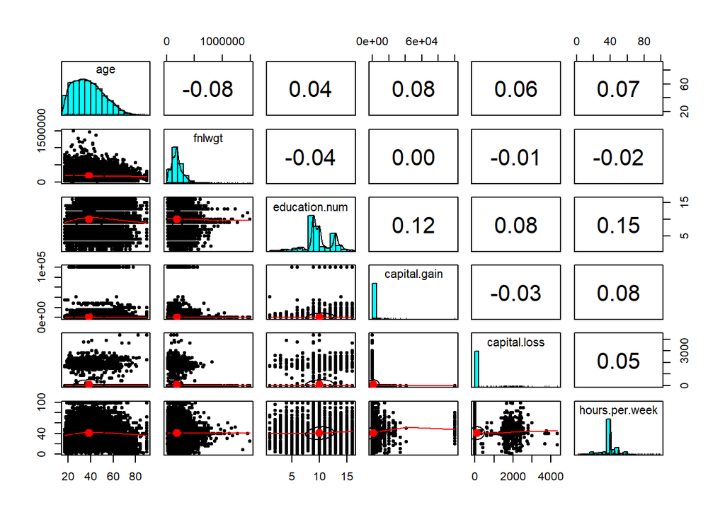

```r
# Pairs.panels
census %>% select(where(is.numeric)) %>% pairs.panels()
```

```r
# correlations
census %>% select(where(is.numeric)) %>% cor()
```

```
##                        age        fnlwgt education.num  capital.gain
## age             1.00000000 -0.0766458679    0.03652719  0.0776744982
## fnlwgt         -0.07664587  1.0000000000   -0.04319463  0.0004318858
## education.num   0.03652719 -0.0431946327    1.00000000  0.1226301147
## capital.gain    0.07767450  0.0004318858    0.12263011  1.0000000000
## capital.loss    0.05777454 -0.0102517117    0.07992296 -0.0316150630
## hours.per.week  0.06875571 -0.0187684906    0.14812273  0.0784086154
##                capital.loss hours.per.week
## age              0.05777454     0.06875571
## fnlwgt          -0.01025171    -0.01876849
## education.num    0.07992296     0.14812273
## capital.gain    -0.03161506     0.07840862
## capital.loss     1.00000000     0.05425636
## hours.per.week   0.05425636     1.00000000
```

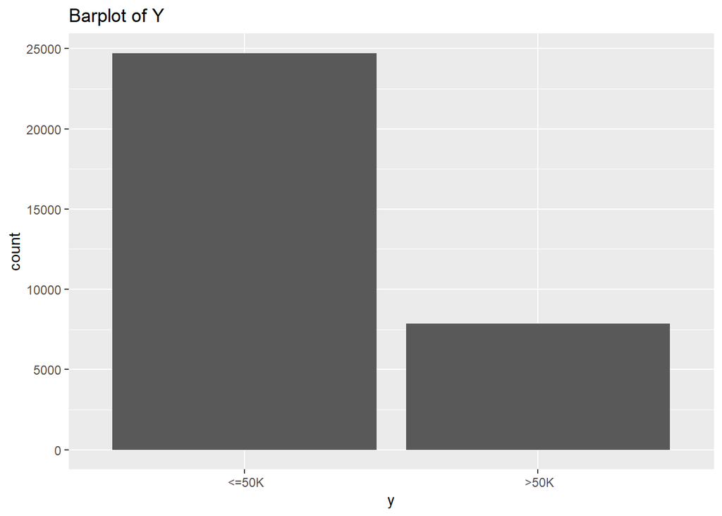

```r
# A barplot for target variable y
census %>% ggplot() +
  geom_bar(aes(x=y)) +
  ggtitle("Barplot of Y")
```

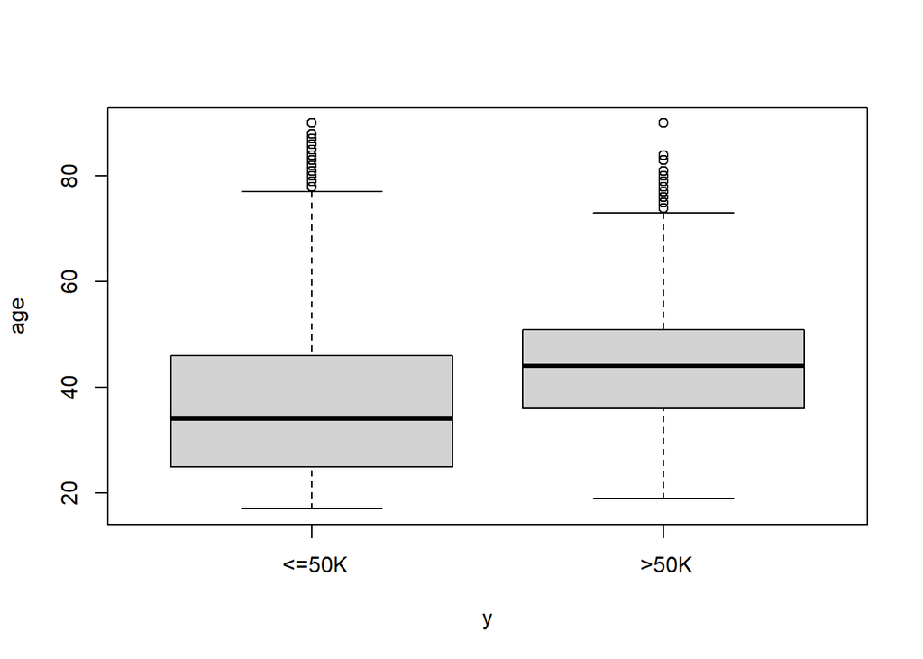

```r
# Boxplot to compare between age, sex, race with target variable y
boxplot(age~y, data = census)
```

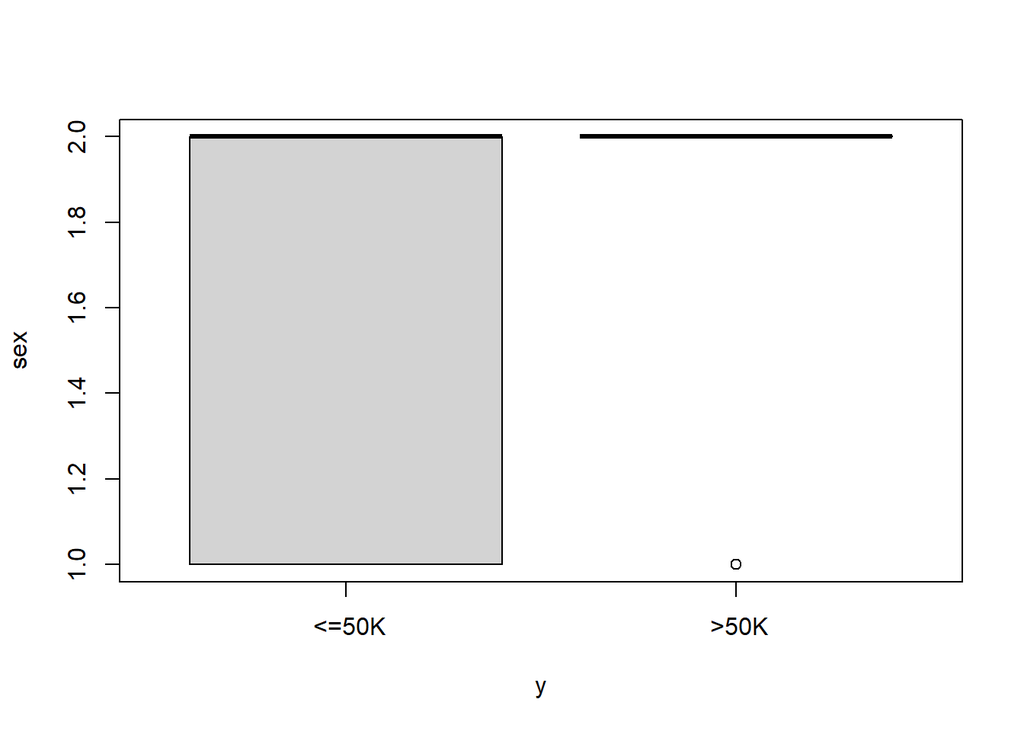

```r
boxplot(sex~y, data = census)
```

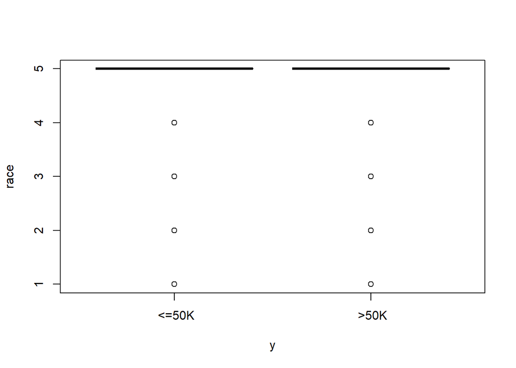

```r
boxplot(race~y, data = census)
```

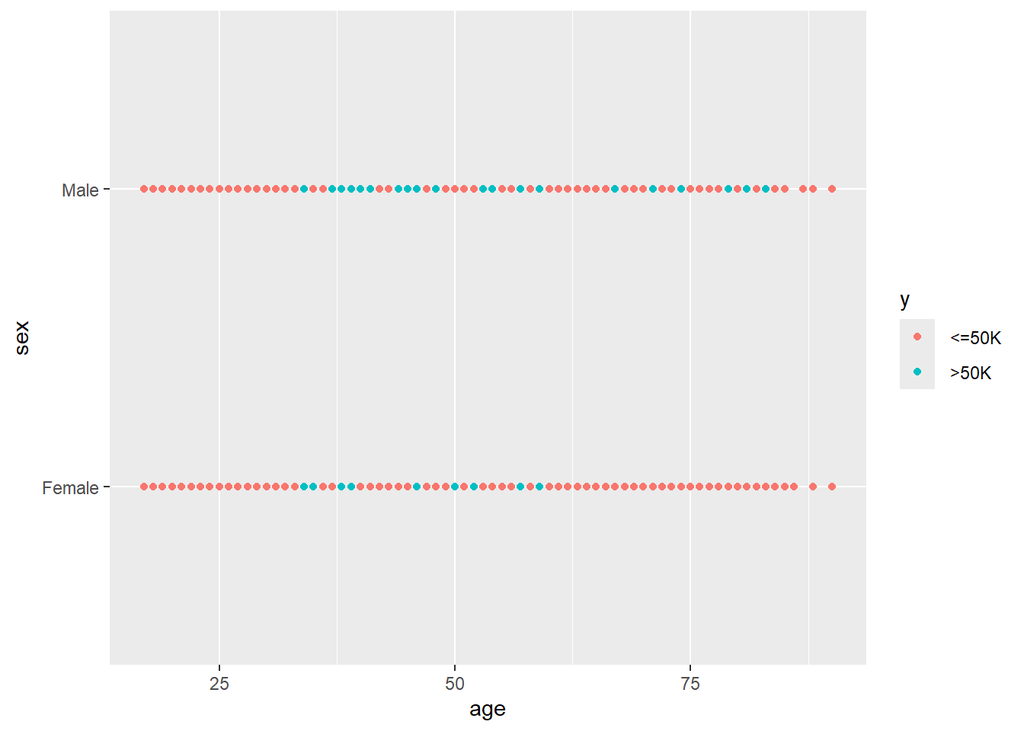

```r
#scatter plot for numeric and factor variables (age, sex and y)
census %>% ggplot() + geom_point(aes(x=age,y=sex,color=y))
```

# Task II - Data Preparation (15%) - Prepare your data for modeling. What tasks should be performed to ensure your model metrics can be used to identify over/underfitting?

- Answers: To handle overfitting or underfitting, I did the finding the missing values, outliers that might skew the model, factorized all the categorical variables. I am going to do data partitioning and splitting in the next few code chunks.

## 2.6 Data preperation

```r
set.seed(100)

index_numbers_split <- createDataPartition(census$y,p=.7,list = FALSE)

train_set <- census[index_numbers_split,-15] #partition the 70% to the train set

summary(train_set)
```

```
##       age                   workclass         fnlwgt
##  Min.   :17.0    Private         :15939   Min.   :  12285
##  1st Qu.:28.0    Self-emp-not-inc: 1789   1st Qu.: 118721
##  Median :37.0    Local-gov       : 1442   Median : 179008
##  Mean   :38.5    ?               : 1257   Mean   : 190561
##  3rd Qu.:47.0    State-gov       :  923   3rd Qu.: 238008
##  Max.   :90.0    Self-emp-inc    :  770   Max.   :1484705
##                 (Other)          :  673
##          education    education.num                  marital.status
##   HS-grad     :7319   Min.   : 1.00    Divorced             : 3117
##   Some-college:5101   1st Qu.: 9.00    Married-AF-spouse    :   18
##   Bachelors   :3766   Median :10.00    Married-civ-spouse   :10416
##   Masters     :1191   Mean   :10.09    Married-spouse-absent:  299
##   Assoc-voc   : 975   3rd Qu.:12.00    Never-married        : 7533
##   11th        : 844   Max.   :16.00    Separated            :  720
##  (Other)      :3597                    Widowed              :  690
##             occupation            relationship                   race
##   Prof-specialty :2889    Husband       :9163    Amer-Indian-Eskimo:  222
##   Craft-repair   :2850    Not-in-family :5912    Asian-Pac-Islander:  716
##   Exec-managerial:2811    Other-relative: 671    Black             : 2173
##   Adm-clerical   :2674    Own-child     :3555    Other             :  183
##   Sales          :2628    Unmarried     :2380    White             :19499
##   Other-service  :2253    Wife          :1112
##  (Other)         :6688
##       sex         capital.gain    capital.loss     hours.per.week
##   Female: 7510   Min.   :    0   Min.   :   0.00   Min.   : 1.00
##   Male  :15283   1st Qu.:    0   1st Qu.:   0.00   1st Qu.:40.00
##                  Median :    0   Median :   0.00   Median :40.00
##                  Mean   : 1104   Mean   :  85.84   Mean   :40.45
##                  3rd Qu.:    0   3rd Qu.:   0.00   3rd Qu.:45.00
##                  Max.   :99999   Max.   :4356.00   Max.   :99.00
##
##         native.country
##   United-States:20399
##   Mexico       :  456
##   ?            :  407
##   Philippines  :  128
##   Germany      :   95
##   Canada       :   87
##  (Other)       : 1221
```

```r
test_set <- census[-index_numbers_split,-15] #simply get the rest of the set and make it test set (30% from the 100%)

summary(test_set)
```

```
##       age                    workclass        fnlwgt
##  Min.   :17.00    Private         :6757   Min.   :  19302
##  1st Qu.:28.00    Self-emp-not-inc: 752   1st Qu.: 115930
##  Median :37.00    Local-gov       : 651   Median : 177140
##  Mean   :38.78    ?               : 579   Mean   : 187952
##  3rd Qu.:48.00    State-gov       : 375   3rd Qu.: 235298
##  Max.   :90.00    Self-emp-inc    : 346   Max.   :1455435
##                  (Other)          : 308
##          education    education.num                  marital.status
##   HS-grad     :3182   Min.   : 1.00    Divorced             :1326
##   Some-college:2190   1st Qu.: 9.00    Married-AF-spouse    :   5
##   Bachelors   :1589   Median :10.00    Married-civ-spouse   :4560
##   Masters     : 532   Mean   :10.07    Married-spouse-absent: 119
##   Assoc-voc   : 407   3rd Qu.:12.00    Never-married        :3150
##   Assoc-acdm  : 334   Max.   :16.00    Separated            : 305
##  (Other)      :1534                    Widowed              : 303
##             occupation            relationship                   race
##   Exec-managerial:1255    Husband       :4030    Amer-Indian-Eskimo:  89
##   Prof-specialty :1251    Not-in-family :2393    Asian-Pac-Islander: 323
##   Craft-repair   :1249    Other-relative: 310    Black             : 951
##   Adm-clerical   :1096    Own-child     :1513    Other             :  88
##   Other-service  :1042    Unmarried     :1066    White             :8317
##   Sales          :1022    Wife          : 456
##  (Other)         :2853
##       sex        capital.gain    capital.loss     hours.per.week
##   Female:3261   Min.   :    0   Min.   :   0.00   Min.   : 1.0
##   Male  :6507   1st Qu.:    0   1st Qu.:   0.00   1st Qu.:40.0
##                 Median :    0   Median :   0.00   Median :40.0
##                 Mean   : 1017   Mean   :  90.71   Mean   :40.4
##                 3rd Qu.:    0   3rd Qu.:   0.00   3rd Qu.:45.0
##                 Max.   :99999   Max.   :4356.00   Max.   :99.0
##
##         native.country
##   United-States:8771
##   Mexico       : 187
##   ?            : 176
##   Philippines  :  70
##   Germany      :  42
##   Puerto-Rico  :  40
##  (Other)       : 482
```

```r
train_target <- census[index_numbers_split,15] #get the train target

test_target <- census[-index_numbers_split,15] #get the test target

#  Set up parameters
metrics_list <- c("MAE","RMSE","MAPE","RMSPE","RAE","RRSE","R2")
metrics_list_two <- c("ACC","PRECISION","TPR","F1")

#set up the tree
c50_model <- C5.0(train_target ~., train_set, control = C5.0Control(CF=0.25), earlyStopping = FALSE, noGlobalPruning =FALSE)

summary(c50_model)
```

```
##
## Call:
## C5.0.formula(formula = train_target ~ ., data = train_set, control
##  = C5.0Control(CF = 0.25), earlyStopping = FALSE, noGlobalPruning = FALSE)
##
##
## C5.0 [Release 2.07 GPL Edition]      Wed Jul 24 20:57:17 2024
## -------------------------------
##
## Class specified by attribute `outcome'
##
## Read 22793 cases (15 attributes) from undefined.data
##
## Decision tree:
##
## capital.gain > 5060:
## :...capital.gain > 6849: >50K (1011/11)
## :   capital.gain <= 6849:
## :   :...marital.status in {Divorced,Married-spouse-absent,Never-married,
## :       :                  Separated,Widowed}: <=50K (35/1)
## :       marital.status in {Married-AF-spouse,
## :                          Married-civ-spouse}: >50K (81/1)
## capital.gain <= 5060:
## :...relationship in {Not-in-family,Other-relative,Own-child,Unmarried}:
##     :...capital.loss > 2206:
##     :   :...race in {Asian-Pac-Islander,Black}: <=50K (7)
##     :   :   race in {Amer-Indian-Eskimo,Other,White}: >50K (62/24)
##     :   capital.loss <= 2206:
##     :   :...capital.gain > 4650:
##     :       :...capital.gain <= 4787: >50K (13)
##     :       :   capital.gain > 4787:
##     :       :   :...relationship in {Not-in-family,Other-relative,
##     :       :       :                Own-child}: <=50K (14)
##     :       :       relationship = Unmarried: >50K (5)
##     :       capital.gain <= 4650:
##     :       :...education in {10th,11th,12th,1st-4th,5th-6th,7th-8th,9th,
##     :           :             Assoc-acdm,Assoc-voc,Bachelors,HS-grad,Masters,
##     :           :             Preschool,Some-college}: <=50K (11989/479)
##     :           education in {Doctorate,Prof-school}: [S1]
##     relationship in {Husband,Wife}:
```

[output cut: 143 more lines]

```
##   95.06% relationship
##   95.06% capital.loss
##   55.37% education
##   39.01% education.num
##   32.59% age
##   26.57% hours.per.week
##   23.12% occupation
##   15.23% race
##    7.00% workclass
##    0.72% native.country
##    0.51% marital.status
##    0.47% fnlwgt
##
##
## Time: 0.2 secs
```

```r
c50_model$size
```

```
## [1] 60
```

# 3 Task III - Model Building (30%) - Build a variety of models and keep them to show your efforts to achieve good performance.

Your stakeholders prefer interpretability over performance. Consider this as you choose your models.

## 3.1 How many models are sufficient? Enough to show that you found underfitting, overfitting and a good balance between the two. Your stakeholders still want a good model however.

## 3.2 Which metrics are appropriate for the prediction task?

## 3.3 Decision Tree Models

```r
# Predict for Train set
tree_cf_train_predictions <- predict(c50_model,train_set)

# Predict for Test set
tree_cf_test_predictions <- predict(c50_model,test_set)

# Confusion matrix Train models
mmetric(train_target, tree_cf_train_predictions, metric="CONF")
```

```
## $res
## NULL
##
## $conf
##         pred
## target    <=50K  >50K
##    <=50K  16299  1005
##    >50K    1797  3692
##
## $roc
## NULL
##
## $lift
## NULL
```

```r
# Confusion matrix Test models
mmetric(test_target, tree_cf_test_predictions, metric="CONF")
```

```
## $res
## NULL
##
## $conf
##         pred
## target    <=50K  >50K
##    <=50K   6932   484
##    >50K     808  1544
##
## $roc
## NULL
##
## $lift
## NULL
```

```r
# Accuracy, Precision, F1, TPR  for Test and Train
mmetric(train_target, tree_cf_train_predictions, metrics_list_two)
```

```
##        ACC PRECISION1 PRECISION2       TPR1       TPR2        F11        F12
##   87.70675   90.06963   78.60336   94.19209   67.26180   92.08475   72.49166
```

```r
mmetric(test_target, tree_cf_test_predictions, metrics_list_two)
```

```
##        ACC PRECISION1 PRECISION2       TPR1       TPR2        F11        F12
##   86.77314   89.56072   76.13412   93.47357   65.64626   91.47532   70.50228
```

## 3.4 Naive Bayes Models

```r
institution_nb <- naiveBayes(train_target ~., data= train_set)


# Predict for Train set with NB institution
nb1_train_predictions <- predict(institution_nb,train_set)

# Predict for Test set with NB institution
nb1_test_predictions <- predict(institution_nb,test_set)

# Confusion matrix
mmetric(test_target, nb1_test_predictions, metric="CONF")
```

```
## $res
## NULL
##
## $conf
##         pred
## target    <=50K  >50K
##    <=50K   6889   527
##    >50K    1184  1168
##
## $roc
## NULL
##
## $lift
## NULL
```

```r
# Evaluate performance
mmetric(train_target,nb1_train_predictions,metrics_list_two) #train target eval
```

```
##        ACC PRECISION1 PRECISION2       TPR1       TPR2        F11        F12
##   82.87193   85.39730   70.50453   93.41193   49.64474   89.22499   58.26384
```

```r
mmetric(test_target,nb1_test_predictions,metrics_list_two) #test target eval
```

```
##        ACC PRECISION1 PRECISION2       TPR1       TPR2        F11        F12
##   82.48362   85.33383   68.90855   92.89374   49.65986   88.95345   57.72177
```

## 3.5 SVM Models

```r
# ksvm on train set
ksvm_default_train <- ksvm(train_target ~.,data = train_set, kernel = "rbfdot", C=4)

# prediction models
pred_ksvm_train <- predict(ksvm_default_train,train_set) #train set predict
pred_ksvm_test <- predict(ksvm_default_train,test_set) #test set predict

# Confusion matrix
mmetric(test_target, pred_ksvm_test, metric="CONF")
```

```
## $res
## NULL
##
## $conf
##         pred
## target    <=50K  >50K
##    <=50K   6908   508
##    >50K     929  1423
##
## $roc
## NULL
##
## $lift
## NULL
```

```r
# Evaluate performance
mmetric(train_target,pred_ksvm_train,metrics_list_two) #train target eval
```

```
##        ACC PRECISION1 PRECISION2       TPR1       TPR2        F11        F12
##   87.92173   89.57733   81.02041   95.16297   65.09382   92.28571   72.18911
```

```r
mmetric(test_target,pred_ksvm_test,metrics_list_two) #test target eval
```

```
##        ACC PRECISION1 PRECISION2       TPR1       TPR2        F11        F12
##   85.28870   88.14597   73.69239   93.14995   60.50170   90.57890   66.44875
```

## 3.6 KNN Model

```r
# IBk on train set
IBk_default_train <- IBk(train_target ~.,data = train_set, control = Weka_control(K=45,X=TRUE, I=TRUE))

# prediction models
pred_IBk_train <- predict(IBk_default_train,train_set) #train set predict
pred_IBk_test <- predict(IBk_default_train,test_set) #test set predict
# Confusion matrix
mmetric(test_target, pred_IBk_test, metric="CONF")
```

```
## $res
## NULL
##
## $conf
##         pred
## target    <=50K  >50K
##    <=50K   6802   614
##    >50K    1007  1345
##
## $roc
## NULL
##
## $lift
## NULL
```

```r
# Evaluate performance
mmetric(train_target,pred_IBk_train,metrics_list_two) #train target eval
```

```
##        ACC PRECISION1 PRECISION2       TPR1       TPR2        F11        F12
##   99.00847   99.05780   98.84908   99.64170   97.01221   99.34889   97.92203
```

```r
mmetric(test_target,pred_IBk_test,metrics_list_two) #test target eval
```

```
##        ACC PRECISION1 PRECISION2       TPR1       TPR2        F11        F12
##   83.40500   87.10462   68.65748   91.72060   57.18537   89.35304   62.39852
```

# 4 Task IV - Reflections (30%)

## 4.1 Model Performance Analysis:

[figure not shown]

Evaluate Performance for these Models.

### 4.1.1 Majority Rule Classifier:

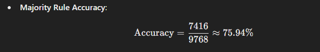

Majority Rule Classifier.

- Assuming the majority class in the dataset is “<=50k” (which has a prevalence of 76%)

### 4.1.2 Random Classifier:

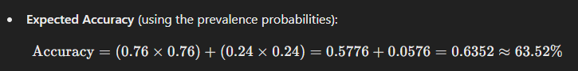

- A random classifier would predict classes based on their prevalence in the training set. For simplicity, we assume a balanced random classifier (predicting “<=50k” 76% of the time and “>50k” 24% of the time)

### 4.1.3 Decision Tree Classifier:

- The Decision Tree classifier has an accuracy of 86.77%.

### 4.1.4 Improvement Over Baseline Models:

- Improvement over Majority Rule Classifier: Improvement=86.77%−75.94%=10.83%
- Improvement over Random Classifier: Improvement=86.77%−63.52%=23.25%

### 4.1.5 Conclusion:

- The Decision Tree classifier is 10.83% more accurate than the majority rule classifier.
- The Decision Tree classifier is 23.25% more accurate than the random classifier.

## 4.2 Interpretation of Results

### 4.2.1 Analysis

#### 4.2.1.1 Precision:

- Precision for <=50k: 89.56%
- Precision for >50k: 76.13%
- The model is more precise in predicting the low income class (<=50k) compared to the high income class (>50k).

#### 4.2.1.2 Recall:

- Recall for <=50k: 93.47%
- Recall for >50k: 65.65%
- The model has a higher recall for the low income class (<=50k), indicating it is better at identifying most of the actual low income individuals.

#### 4.2.1.3 F1 Score:

- F1 Score for <=50k: 91.48%
- F1 Score for >50k: 70.50%
- The F1 score, which is the harmonic mean of precision and recall, is higher for the low income class (<=50k), suggesting that the model performs better overall for this class. #### Conclusion:
- The model is better at predicting those with low income (<=50k) compared to high income (>50k). This is indicated by higher precision, recall, and F1 scores for the low income class. The model has a better balance of precision and recall for the low income class, making it more effective at correctly identifying low income individuals.

### 4.2.2 SVM:

- High accuracy and precision for the “<=50k” class but lower precision and recall for the “>50k” class.
- Better at predicting low-income individuals accurately.

### 4.2.3 Naive Bayes:

- Lower precision and recall for the “>50k” class, leading to lower overall accuracy and F1 scores.
- More likely to misclassify high-income individuals as low-income.

## 4.3 Why Chosen these models

### 4.3.1 1. Naive Bayes

Naive Bayes is a simple and effective probabilistic classifier based on Bayes’ theorem with strong (naive) independence assumptions between the features. It is particularly useful for classification tasks for several reasons:

- Simplicity and Speed: Naive Bayes is computationally efficient, making it suitable for large datasets.
- Robustness to Irrelevant Features: Naive Bayes can handle irrelevant features well because it assumes feature independence.
- Works Well with Categorical Data: The algorithm handles categorical data effectively and can be used in various classification problems.
- Interpretable: The model provides clear probabilities for class membership, making it easy to understand the decision-making process.

### 4.3.2 2. Decision Tree

Decision Trees are versatile and widely-used algorithms for classification and regression tasks. Here are the key reasons for choosing Decision Trees:

- Interpretability: Decision trees provide a clear, visual representation of decisions, which stakeholders can easily understand. Handling Non-linear Relationships: Decision trees can capture non-linear relationships between features and the target variable.
- No Need for Feature Scaling: Unlike some algorithms, decision trees do not require feature scaling or normalization. Feature Importance: Decision trees can rank features based on their importance, providing insights into which features are most influential in predicting the target variable.
- Flexibility: Decision trees can be used for both classification and regression tasks and can handle both categorical and continuous data.

### 4.3.3 3. k-Nearest Neighbors (k-NN)

- k-Nearest Neighbors (k-NN) is a simple, instance-based learning algorithm that classifies data points based on the majority class among their nearest neighbors.
- Simplicity: k-NN is easy to understand and implement. It doesn’t involve any complex parameter tuning or model training.
- Non-parametric: k-NN is a non-parametric method, meaning it makes no assumptions about the underlying data distribution. This can be beneficial for datasets with complex distributions.
- Versatility: k-NN can handle both classification and regression tasks, making it a flexible choice for various problems. Performance: With the right choice of k and appropriate distance metric, k-NN can provide competitive performance, especially for smaller datasets or datasets where the class boundaries are well-defined.
- Local Decision Making: k-NN makes decisions based on local neighborhoods, which can be useful if the decision boundaries are highly irregular.

### 4.3.4 4. Support Vector Machine (SVM)

- Support Vector Machines (SVM) are powerful classifiers that work by finding the hyperplane that best separates the classes in the feature space.
- Effective in High Dimensional Spaces: SVM performs well in spaces with many dimensions, which is useful when the dataset has a large number of features.
- Margin Maximization: SVM focuses on maximizing the margin between classes, which can lead to better generalization and performance.
- Flexibility with Kernels: SVMs can use different kernel functions (linear, polynomial, radial basis function, etc.) to handle non-linear decision boundaries. This makes SVMs highly flexible and capable of modeling complex relationships.
- Regularization: SVM includes regularization parameters (like C and gamma), which help in preventing overfitting and improving model robustness.
- Versatility: Like k-NN, SVM can handle both classification and regression tasks, making it a versatile choice for various types of problems.

## 4.4 Additional Questions:

### 4.4.2 Data Splitting Method:

- Method: Data was split using stratified sampling to ensure both training and testing sets have a similar distribution of the target variable.
- Reason: This method ensures that the model is trained and evaluated on representative samples of the data, preventing biases due to uneven class distribution.